# Tests d’hypothèses pour l’analyse bivariée

2eme-FA-EMS - BUT SD - E. Anakok

# 1 Que va contenir ce cours ?

## 1.1 Organisation et évaluation

- 10 séances de cours-TD-TP de 3h00.
- plusieurs DST + 2 TP notés
- Dépôt des documents de cours, TD, TP sur moodle.

## 1.2 Compétences, Ressources, SAE

- **Ressource : RES R3.06** : Tests d’hypothèses pour l’analyse bi-variée, s’appuie très fortement sur la ressource du S2, R2.08 : Statistique inférentielle
- **Compétence ciblée** : Analyser statistiquement les données, Niveau 2 : Mettre en oeuvre une analyse exploratoire
- **Apprentissages critiques** :
  - **AC22.04** : Appréhender l’idée de confronter une hypothèse avec la réalité pour prendre une décision
  - **AC22.05** : Apprécier les limites de validité et les conditions d’application d’une analyse
- **SAÉ concernées** :
  - Au S3 - **SAÉ 3.EMS.01** : Recueil et analyse de données par échantillonnage ou plan d’expérience
  - Au S4 - **SAÉ 4.EMS.01** : Expliquer ou prédire une variable quantitative à partir de plusieurs facteurs

## 1.3 Plan du cours

- **Rappels**
- **Chapitre I** : Introduction sur les tests
- **Chapitre II** : Tests paramétriques à un échantillon
- **Chapitre III** : Test paramétriques de comparaison de deux échantillons
- **Chapitre IV** : Test du $\chi^2$
- **Chapitre V** : Tests de corrélation

## 1.4 Le code couleur

**WarningJaune**

Ceci est un objectif.

**NoteBleu**

Ceci est un rappel, une définition ou un exemple.

**TipVert**

Ceci est un résultat, un théorème.

**CautionOrange**

Ceci est une remarque.

## 1.5 Ce qu’il faut retenir de ce cours

**NoteDéfinition : Quantile**

Le quantile $u\in [0,1]$ de la v.a. $X$ est le nombre réel $q_u$ tel que

$$P(X\leq q_u ) = u$$

**TipThéorème central limite**

Soit $(X_i)_{i\in\mathbb{N}}$ une suite de v.a. i.i.d. d’espérance $\mu$ et de variance $\sigma^2$ finies. Alors,

$$\sqrt{n} \frac{(\bar{X}_n - \mu)}{\sigma} \xrightarrow[n\rightarrow\infty]{\mathscr{L}}\mathcal{N}(0,1)$$

**NoteDéfinition : Test statistique**

C’est une démarche de statistique inférentielle, qui permet à partir d’observations de valider ou d’invalider des hypothèses, en contrôlant le risque de se tromper.

**NoteÉtapes d’un test statistique**

1. Modélisation des données
2. Hypothèse nulle et hypothèse alternative
3. Choix d’une statistique de test
4. Déterminer la zone de rejet $R_\alpha$
5. Mise en œuvre du test, application numérique
6. Calculer la $p$-valeur
7. (Si possible) Calculer la puissance du test

# 2 Rappel

## 2.1 Probabilité

**NoteDéfinition informelle**

Une probabilité est une fonction qui mesure à quel point on s’attend à ce que qu’un événement se produise, dans une expérience où le résultat n’est pas connu à l’avance (une expérience aléatoire).

**NoteDéfinition mathématique**

- $\Omega$ : L’ensemble des événements possibles.
- $\mathbb{P}$ est une mesure de probabilité sur $\Omega$ si :
  - Pour $A\subset \Omega,\quad 0 \leq \mathbb{P}(A)\leq 1$
  - $\mathbb{P}(\Omega) = 1$
  - Si $A,B\subset \Omega$ et $A\cap B = \varnothing$ alors $\mathbb{P}(A\cup B) = \mathbb{P}(A) + \mathbb{P}(B)$

**CautionRemarques**

Si $\mathbb{P}(A) = 0$ alors l’événement $A$ est impossible.

Si $\mathbb{P}(A) = 1$ alors l’événement $A$ est certain.

## 2.2 Variable aléatoire et loi

**NoteDéfinition : variable aléatoire**

Une variable aléatoire $X$ est une fonction qui associe à chaque événement un nombre réel.
$$X: \Omega \rightarrow \mathbb{R}$$

**NoteDéfinition : loi de probabilité**

Une loi de probabilité est une fonction qui associe à chaque valeur possible de $X$ une probabilité.

**NoteLoi discrète**

$X$ prend un nombre fini ou dénombrable de valeur.

**NoteExemple**

- Loi Benroulli $\mathcal{B}(p)$
- Loi Binomial $\mathcal{B}(n,p)$
- Loi de Poisson $\mathcal{P}(\lambda)$

**NoteLoi continue**

$X$ prend un nombre indénombrable de valeur.

**NoteExemple**

- Loi uniforme $U$
- Loi exponentielle $\varepsilon(\lambda)$
- Loi de Student $\mathcal{T}(n)$
- Loi normale $\mathcal{N}(\mu,\sigma^2)$
- Loi du $\chi^2$

## 2.3 Densité

**NoteDéfinition : densité de probabilité**

Une variable aléatoire continue $X$ admet $f$ comme densité de probabilté si

$$\mathbb{P}(a\leq X \leq b) = \int_a^b f(x)dx$$

**NoteExemple : $\mathcal{N}(0,1)$**

La loi $\mathcal{N}(0,1)$ a pour densité de probabilité $f(x)= \frac{1}{\sqrt{2\pi}}e^{-\frac{1}{2}x^2}$

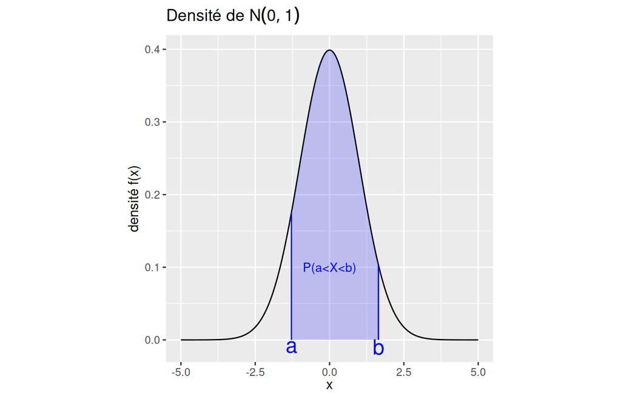

## 2.4 Fonction de répartition

**NoteDéfinition**

La fonction de répartition $F$ de la v.a. $X$ est défini par :

$$\begin{align}
F :\mathbb{R} & \longrightarrow [0,1]\\
s & \longrightarrow \mathbb{P}(X\leq s)
\end{align}$$

**CautionRemarques**

- $F$ est croissante
- $\underset{s\rightarrow - \infty}{\lim} F(s) = 0$
- $\underset{s\rightarrow + \infty}{\lim} F(s) = 1$

## 2.5 Visualisation de la fonction de répartition

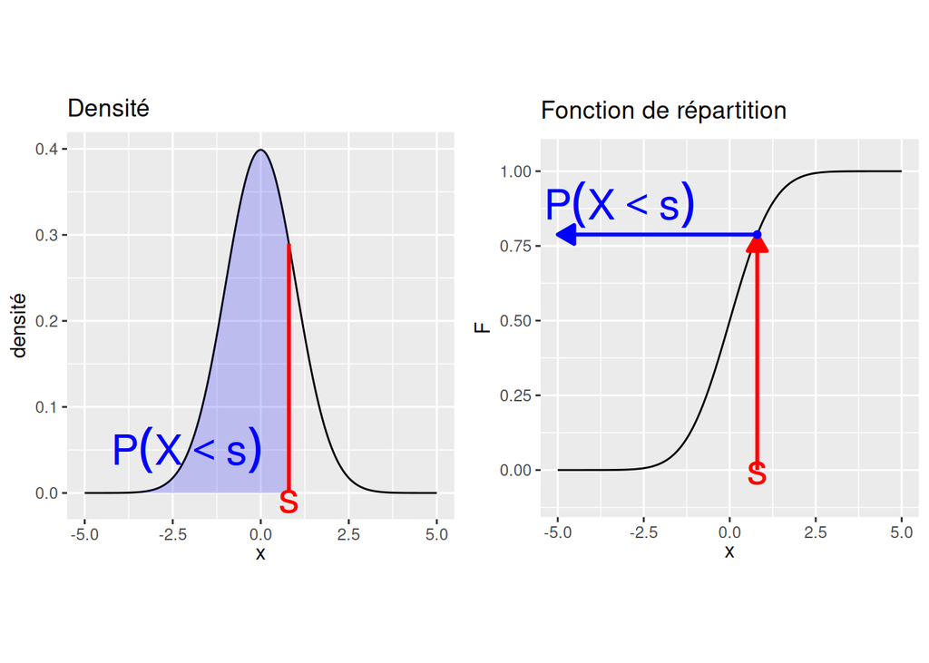

$$\begin{align}
\color{red}{\text{entrée}} & \longrightarrow \color{blue}{\text{sortie}}\\
\color{red}{\mathbb{R}} & \longrightarrow \color{blue}{[0,1]}\\
\color{red}{s} & \longrightarrow \color{blue}{\mathbb{P}(X\leq s)}\\
\end{align}$$

## 2.6 Fonction quantile

**NoteDéfinition**

La fonction quantile $q$ de la v.a. $X$ est **l’inverse de la fonction de répartition**

$$\begin{align}
q :[0,1] & \longrightarrow \mathbb{R} \\
u & \longrightarrow F^{-1}(u) := q_u\\
\end{align}$$

**CautionRemarques**

Interprétation : pour $u\in [0,1]$, $q_u$ est le nombre réel tel que

$$\mathbb{P}(X\leq q_u ) = u$$

## 2.7 Visualisation de la fonction quantile

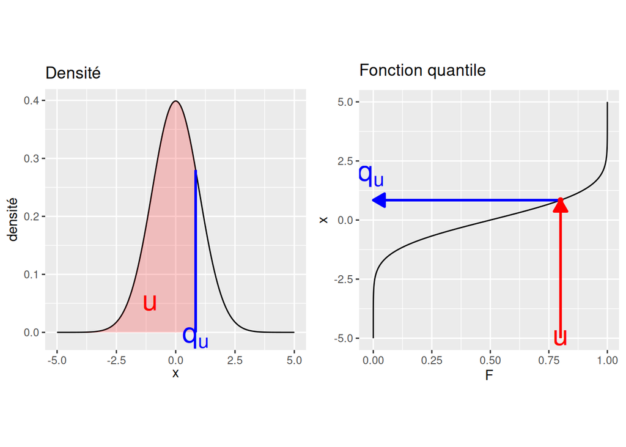

$$\begin{align}
\color{red}{\text{entrée}} & \longrightarrow \color{blue}{\text{sortie}}\\
\color{red}{[0,1]} & \longrightarrow \color{blue}{\mathbb{R}}\\
\color{red}{u} & \longrightarrow \color{blue}{q_u\quad\text{ tel que }\mathbb{P}(X\leq q_u) = u}\\
\end{align}$$

## 2.8 Une propriété du quantile

**TipThéorème**

Pour les lois symmétriques et centrées, on a

$$q_{1-u} = -q_u$$

**NoteExemple**

La loi $\mathcal{N}(0,1)$ est symmétrique et centrée.

$q_{0.975} = 1.96$

$q_{0.025} = -1.96$

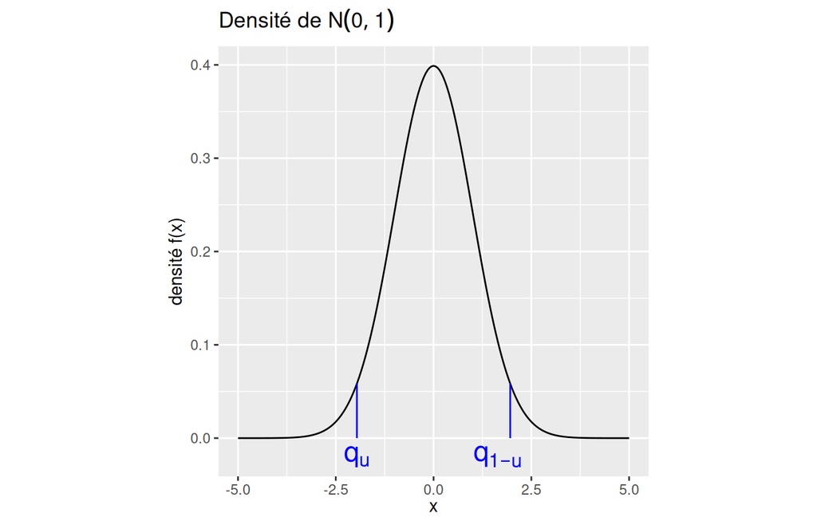

## 2.9 Lire un quantile : version *Old school*

**NoteTable de quantile**

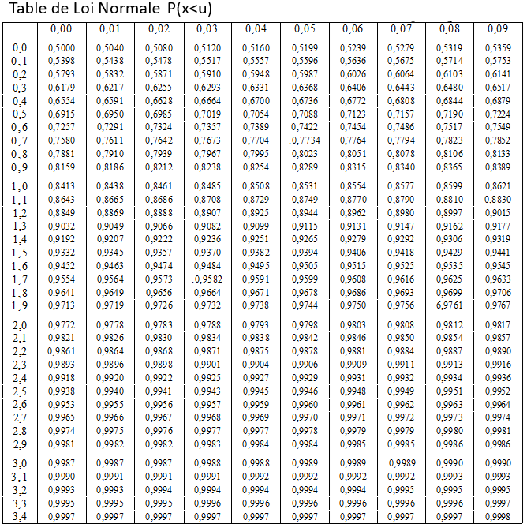

## 2.10 Lire un quantile : Code R

```r
qnorm(0.975)
```

```
[1] 1.959964
```

```r
qnorm(0.025)
```

```
[1] -1.959964
```

```r
qt(0.975, df = 25)
```

```
[1] 2.059539
```

### 2.10.1 À retenir :

**NoteDéfinition : quantile**

Le quantile $u\in [0,1]$ de la v.a. $X$ est le nombre réel $q_u$ tel que

$$P(X\leq q_u ) = u$$

## 2.11 Théorème centrale limite : Égalité en loi

**TipThéorème**

Si deux variables aléatoires $X$ et $Y$ suivent la même loi, alors :

- $X$ et $Y$ ont la même fonction de répartition.
- $X$ et $Y$ ont les mêmes quantiles.

**NoteDéfinition : Convergence en loi**

Soit $(X_i)_{i\in\mathbb{N}}$ une suite de v.a. et $X_\infty$ une v.a., on dit que $(X_i)_{i\in\mathbb{N}}$ **converge en loi** vers $X_\infty$ si pour tout réel $x$ on a

$$\lim_{i\rightarrow\infty}\mathbb{P}(X_i\leq x) = \mathbb{P}(X_\infty\leq x)$$

**CautionRemarques**

Autrement dit, les **fonctions de répartition** des $X_i$ converge ponctuellement vers la **fonctions de répartition** de $X_\infty$, on notera $X_i \xrightarrow[i\rightarrow\infty]{\mathscr{L}} X_\infty$

## 2.12 Le Théorème central limite

Le théorème central limite (TCL) est un résultat général sur la loi de $\bar{X}_n$ lorsque $n$ est suffisamment grand, **quelle que soit la loi des** $X_i$.

**TipThéorème central limite**

Soit $(X_i)_{i\in\mathbb{N}}$ une suite de v.a. i.i.d. d’espérance $\mu$ et de variance $\sigma^2$ finies. Alors,

$$\sqrt{n} \frac{(\bar{X}_n - \mu)}{\sigma} \xrightarrow[n\rightarrow\infty]{\mathscr{L}}\mathcal{N}(0,1)$$

## 2.13 La convergence en loi illustrée

- On choisit une loi quelconque d’espérance $\mu$ et de variance finie $\sigma$.
- Pour $n$ fixé, on simule $(x_i)_{1\leq i \leq n}$ selon cette loi et on calcule $t_n = \sqrt{n} \frac{(\bar{x}_n - \mu)}{\sigma}$.
- On repète cette expérience plusieurs fois pour voir la distribution des $t_n$ obtenus.

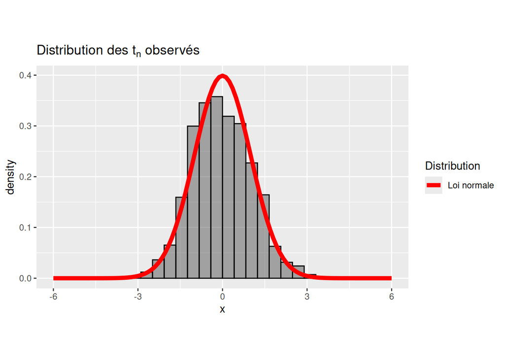

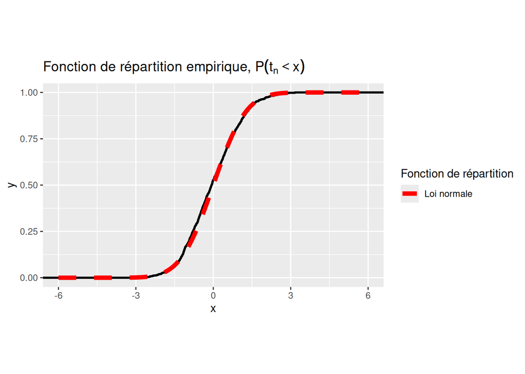

## 2.14 Rappel: le Théorème central limite

- Lorsque $n$ est grand, on pourra rapprocher la loi de $\bar{X}_n$ par la loi $\mathcal{N}\left(\mu,\frac{\sigma^2}{n}\right)$.
- On notera pour simplifier $\bar{X}_n\approx \mathcal{N} \left(\mu,\frac{\sigma^2}{n}\right)$.
- “Lorsque $n$ est grand”$\approx$ “$n>30$”.
- Si on ne connaît pas la variance $\sigma^2$ des $X_i$, on la remplace par un **estimateur consistant** $S^2$, et le TCL reste encore valide.

$$\sqrt{n}\frac{(\bar{X}_n - \mu)}{S}\xrightarrow[n\rightarrow\infty]{\mathscr{L}}\mathcal{N}(0,1)$$

## 2.15 Ce qu’il faut retenir de ce cours

**NoteDéfinition : Quantile**

Le quantile $u\in [0,1]$ de la v.a. $X$ est le nombre réel $q_u$ tel que

$$P(X\leq q_u ) = u$$

**TipThéorème central limite**

Soit $(X_i)_{i\in\mathbb{N}}$ une suite de v.a. i.i.d. d’espérance $\mu$ et de variance $\sigma^2$ finies. Alors,

$$\sqrt{n} \frac{(\bar{X}_n - \mu)}{\sigma} \xrightarrow[n\rightarrow\infty]{\mathscr{L}}\mathcal{N}(0,1)$$

**NoteDéfinition : Test statistique**

C’est une démarche de statistique inférentielle, qui permet à partir d’observations de valider ou d’invalider des hypothèses, en contrôlant le risque de se tromper.

**NoteÉtapes d’un test statistique**

1. Modélisation des données
2. Hypothèse nulle et hypothèse alternative
3. Choix d’une statistique de test
4. Déterminer la zone de rejet $R_\alpha$
5. Mise en œuvre du test, application numérique
6. Calculer la $p$-valeur
7. (Si possible) Calculer la puissance du test

# 3 Introduction sur les tests statistiques

## 3.1 Exemple 1 : la salmonelle

Plusieurs personnes ont souffert d’intoxication alimentaire de salmonelle. Après enquête, on suspecte une marque de glaces d’être responsable de l’intoxication. Pour vérifier cela, des scientifiques ont mesuré le niveau de salmonelle dans 9 pots de glace, tirés de façon aléatoire chez le fabricant de glace. On obtient les mesures suivantes, exprimées en NPP (Nombre le Plus Probable) par gramme :

```r
x<- c(0.175, 0.205, 0.760, 0.719, 0.199, 0.529, 0.306, 0.520, 0.010)
```

- On sait que le niveau de référence que doit respecter un fabricant de glaces est de 0.3 NPP/g.
- La question que l’on se pose est : le niveau moyen de salmonelle dans les pots de glace est-il supérieur à 0.3 ?

```r
mean(x)
```

```
[1] 0.3803333
```

## 3.2 Exemple 1 : la salmonelle

[figure not shown]

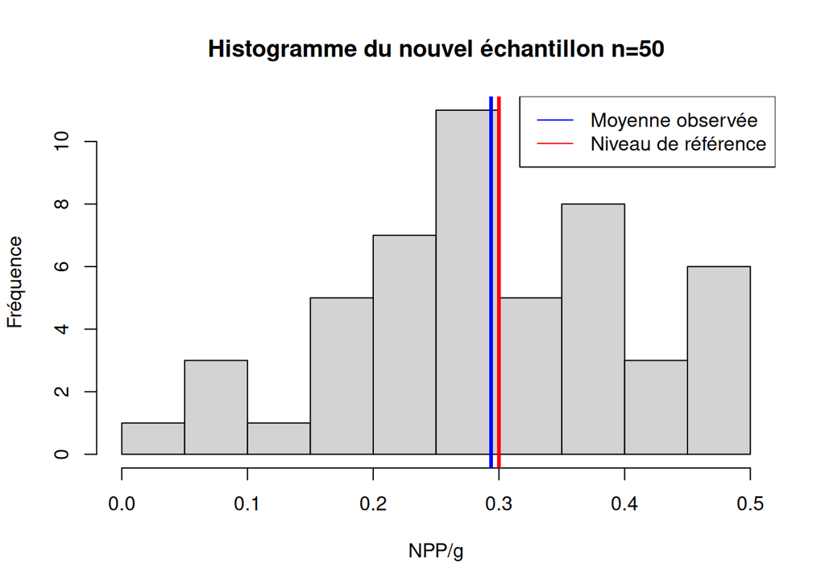

## 3.3 Exemple 2 : insecticides

Pour comparer l’effet entre deux insecticides, on applique l’insecticide A et B sur 36 groupes de 30 insectes et après avoir laissé agir pendant une heure, on compte le nombre d’insectes morts.

On obtient pour l’insecticide A, les nombres d’insectes tués suivants :

```r
A<- c(14, 2, 21, 5, 20, 2, 17, 3, 11, 7,
      11, 3, 5, 23, 1, 4, 16, 10, 3, 6, 4,
      1, 5, 1, 14, 13, 4, 3, 24, 14, 9, 5, 21, 17, 15, 6)

print(mean(A))
```

```
[1] 9.444444
```

Pour l’insecticide B, les nombres d’insectes tués sont :

```r
B<- c(1, 26, 2, 5, 17, 13, 15, 3, 26, 14, 1,
      19, 5, 1, 11, 2, 4, 20, 3, 10, 3, 3, 0,
      22, 7, 12, 13, 5, 13, 6, 0, 10, 16, 7, 12, 17)
print(mean(B))
```

```
[1] 9.555556
```

A partir de ces résultats, peut-on dire que l’insecticide B fonctionne mieux que le A ?

## 3.4 Exemple 2 : insecticides

- Résultat sur l’échantillon A et B

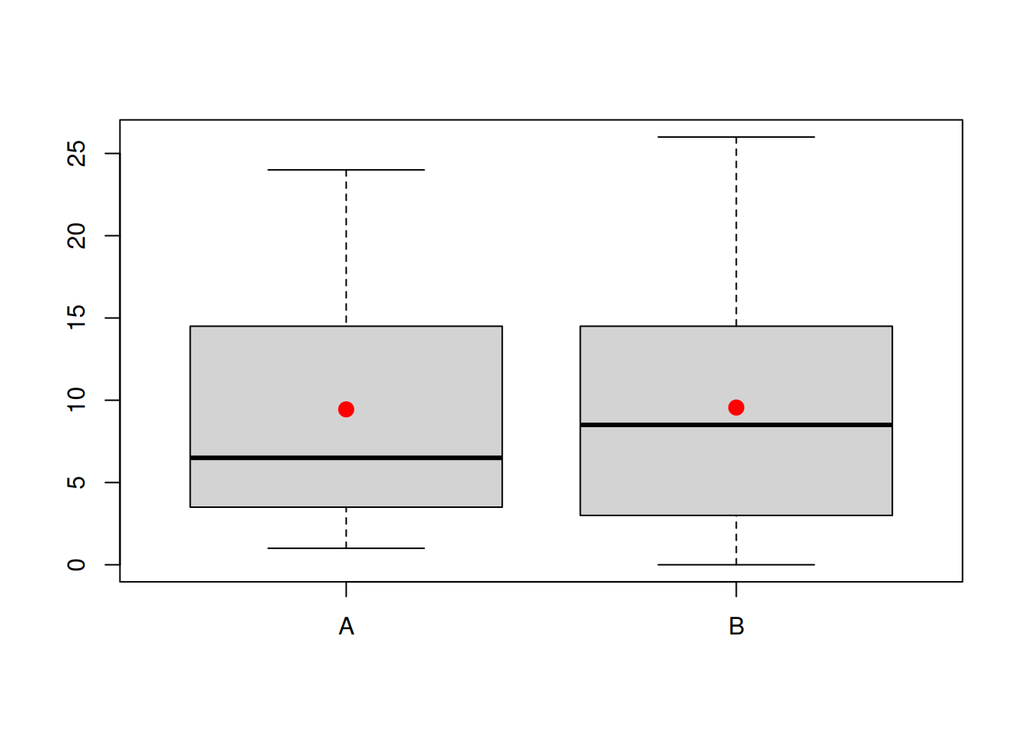

```r
#| out-width: 80%
boxplot(A,B,names= c("A","B"))
points(x=c(1,2),
       y = c(mean(A),mean(B)),
       pch=20,col = "red",cex=2)
```

- Si on pouvait recommencer l’expérience, pourrait-on parfois avoir la moyenne du nombre d’insectes tués par l’insecticide A qui soit supérieure au nombre d’insectes tués par l’insecticide B ?
- Le problème est qu’en pratique, on ne dispose que d’un échantillon.

## 3.5 Exemple 3 : tabagisme

Dans le cadre d’une enquête sur le comportement des jeunes vis-à-vis de la cigarette, on sonde un panel de lycéennes et de lycéens. Les observations suivantes ont été obtenues. Y a-t-il un lien entre genre et tabagisme ?

Effectifs

|  | Fumeur | Non Fumeur |
| --- | --- | --- |
| Femme | 12 | 38 |
| Homme | 63 | 137 |

Fréquences

|  | Fumeur | Non Fumeur |
| --- | --- | --- |
| Femme | 0.240 | 0.760 |
| Homme | 0.315 | 0.685 |

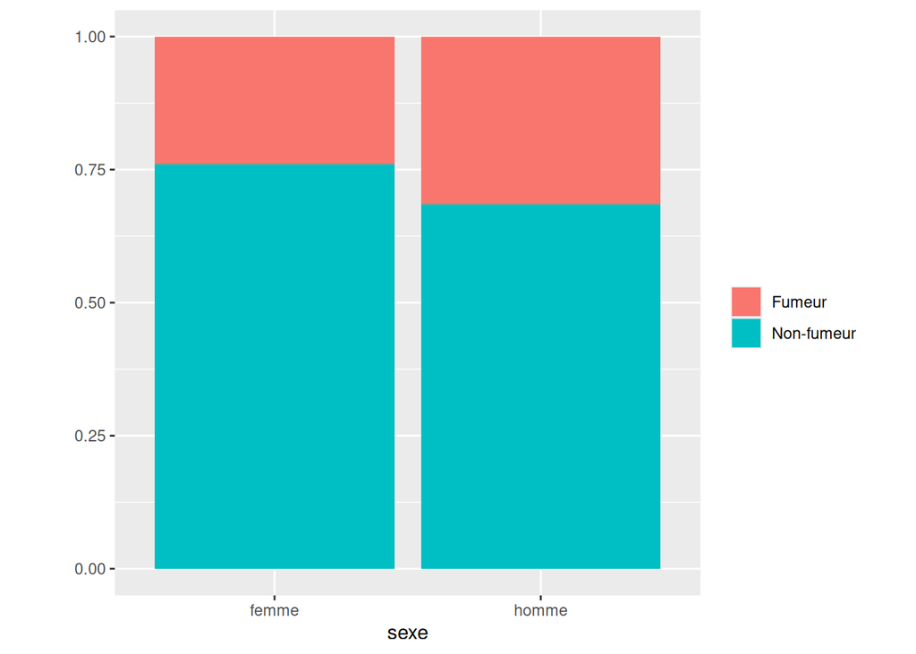

## 3.6 L’objectif

**WarningObjectif**

Valider ou non une hypothèse faite sur une (ou plusieurs) population(s).

À partir des données de l’échantillon, on souhaite choisir entre :

- L’hypothèse nulle $H_0$
- L’hypothèse alternative $H_1$

**NoteExemple**

Pour les pots de glace et la salmonelle, on souhaite tester :

- $H_0$ : “NON : la quantité de salmonelle des pots de glace **ne dépasse pas** le niveau réglementaire de 0.3 NPP/g”.
- $H_1$ : “OUI : la quantité de salmonelle des pots de glace **dépasse** le niveau réglementaire de 0.3 NPP/g”.

## 3.7 Comment montrer qu’une proposition est vraie ?

**WarningObjectif**

On souhaite montrer qu’une proposition est vraie.

**TipComment faire ?**

En mathématique, on vérifie que les propositions sont vraies à l’aide de **démonstrations**.

**NoteExemple de démonstrations**

- Démonstration directe
- Démonstration par contraposée
- Démonstration par récurrence
- **Démonstration par l’absurde**
- …

## 3.8 Démonstration par l’absurde

**Exercice** : Démontrez par l’absurde que $\sqrt{2}$ est irrationnel.

**Démonstration par l’absurde**

**NoteModélisation**

$\sqrt{2}$ est un nombre positif tel que $\sqrt{2}^2 = 2$

**NoteHypothèses**

- $H_0$ : $\sqrt{2}$ est rationnelle
- $H_1$ : $\sqrt{2}$ est irrationnelle

**NoteRaisonnement**

Supposons que $H_0$ est vraie. Dans ce cas,

- Il existe 2 nombres premiers entre eux $a$ et $b$ tels que $\sqrt{2} = \frac{a}{b}$.
- On a alors $2b^2 = a^2$. Puisque $a^2$ est pair, $a$ est pair, on a donc $a=2p$.
- $2 b^2 = (2p)^2 = 4p^2$ donc $b^2 = 2p^2$ donc $b$ est pair.
- $a$ et $b$ sont des multiples de 2, ils ne sont donc pas premiers entre eux.

**NoteEst-ce possible ?**

On aboutit à une contradiction

**NoteConclusion**

On rejette l’hypothèse $H_0$ et on conserve l’hypothèse $H_1$

**Test statistique : similaire à démonstration par l’absurde mais probabiliste**

**NoteModélisation**

Les données $x_i$ sont des réalisations i.i.d. d’une v.a. $X_i$

**NoteHypothèses**

- $H_0$ : “NON : la quantité de salmonelle **ne dépasse pas** le niveau réglementaire
- $H_1$ : “OUI : la quantité de salmonelle **dépasse** le niveau réglementaire

**NoteRaisonnement**

Supposons que $H_0$ est vraie. Dans ce cas,

- À partir des variables aléatoire $X_i$, on va construire une statistique de test $T_n$.
- On s’attend à ce $T_n$ suive une certaine loi de probabilité.
- À partir des données, on a observé la réalisation $t_n$

**NoteEst-ce possible ?**

$t_n$ se produit avec une probabilité de $p_c$ (probabilité critique).

**NoteConclusion**

Si $p_c$ est trop petite : On rejette $H_0$ et on affirme $H_1$.

Sinon : On ne rejette pas $H_0$, on n’a pas suffisament de preuve pour affirmer $H_1$.

## 3.9 Risques

- $H_0$ : “la quantité de salmonelle des pots de glace **ne dépasse pas** le niveau réglementaire de 0.3 NPP/g”.
- $H_1$ : “la quantité de salmonelle des pots de glace **dépasse** le niveau réglementaire de 0.3 NPP/g”.

2 types d’erreurs possibles :

- Si $H_0$ est vraie, on peut se tromper en choisissant $H_1$. C’est le **risque de première espèce**, appelé aussi “faux positif”.
- Si $H_1$ est vraie, on peut se tromper en choisissant $H_0$. C’est le **risque de deuxième espèce**, appelé aussi “faux négatif”.

## 3.10 Risques

**CautionRemarques**

Les deux risques ne sont pas symétriques. Selon le consommateur ou le fabricant il y a un risque plus grave que l’autre. Cela dépend du point de vue.

- Pour le fabricant, le plus grave est de dire que sa glace peut être dangereuse pour la santé alors qu’elle ne l’est pas.
- Pour le consommateur, le plus grave est de dire que la glace n’est pas dangereuse pour la santé alors qu’elle l’est.

En pratique on n’arrive généralement pas à contrôler les deux risques. Il faut choisir ce que l’on veut montrer et quel risque on veut contrôler.

## 3.11 Quantifier les risques

Peut-on quantifier à quel point on se trompe ?

**NoteDéfinition : Risque de première espèce**

- $\alpha$ est le risque de première espèce, ou le **taux de faux positif**.

$$\alpha = \mathbb{P}(\text{rejeter à tort }H_0) = \mathbb{P}_{H_0}(\text{rejeter }H_0)$$

**NoteDéfinition : risque de deuxième espèce**

- $\beta$ est le risque de **deuxième espèce**, ou le **taux de faux négatif**.

$$\beta = \mathbb{P}(\text{accepter à tort }H_0) = \mathbb{P}_{H_1}(\text{accepter }H_0)$$

**NoteMatrice de confusion**

|  | Décision : $H_0$ | Décision : $H_1$ |
| --- | --- | --- |
| Réalité : $H_0$ | $1-\alpha$ | $\alpha$ |
| Réalité : $H_1$ | $\beta$ | $1-\beta$ |

**CautionRemarques**

Si on veut estimer ces probabilités, alors les observations doivent suivre un **modèle probabiliste**.

## 3.12 Quantifier les risques

**CautionRemarques**

- En pratique, le risque de 1ère espèce $\alpha$ est fixé à l’avance aussi petit que l’on veut (5%, 10%), c’est un risque qu’on va essayer de contrôler.
- Si on arrive à le contrôler, alors on connait le pourcentage d’erreur de se tromper quand on rejette $H_0$.
- Dans certaines condition, on peut essayer de contrôler $\beta$, le risque de 2ème espèce. Si on ne le fait pas, on ne connait pas la marge d’erreur que l’on commettrait en conservant $H_0$.

## 3.13 Qu’est-ce qui influence le risque ?

- **Échantillons choisis**. En pratique, on ne dispose que d’un échantillon. Est-ce que l’échantillon est bien représentatif des données ? Est-on en présence d’un échantillon atypique ?
- **Taille des échantillons**. Plus l’échantillon est grand, plus il sera facile de discriminer entre deux hypothèses.
- **Variance des observations**. Plus la variance est faible, plus il sera facile de discriminer entre deux hypothèses.

Qui a la moyenne la plus élevé entre A et B ? Dans le graphique suivant, le risque de se tromper est élevé.

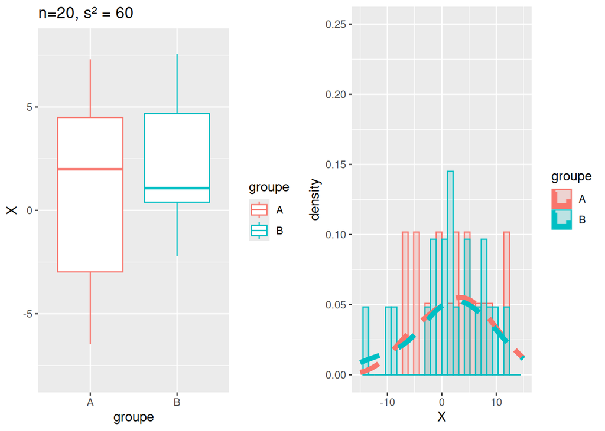

Par contre, dans le graphique qui suit, le risque de se tromper est plus faible.

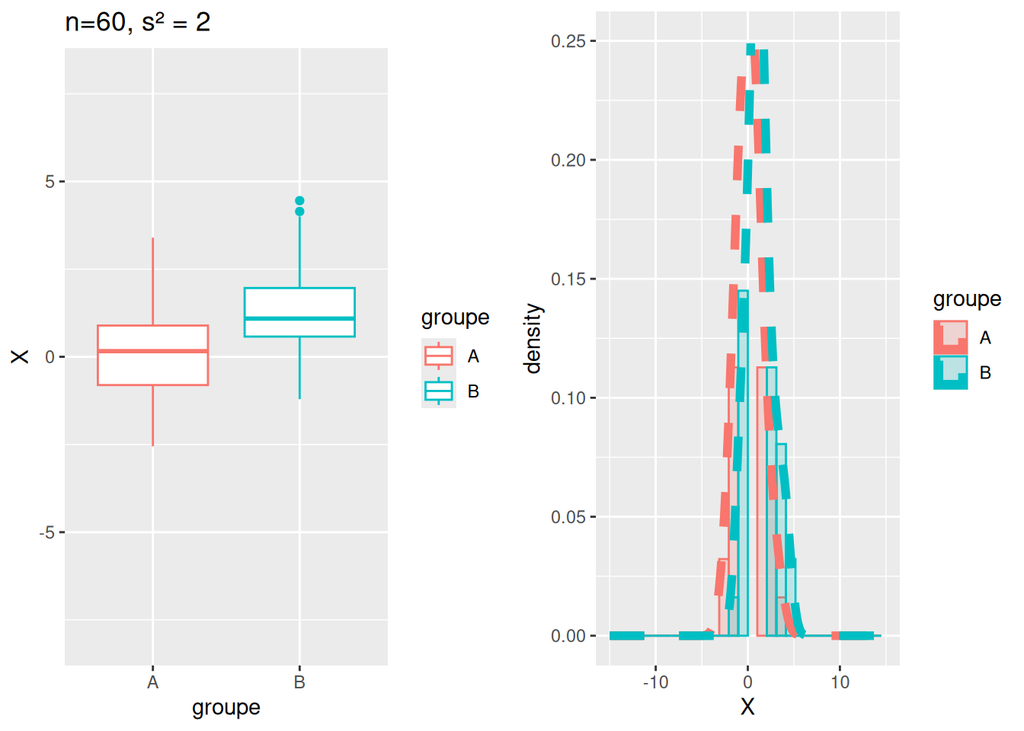

# 4 Construire un test statistique

## 4.1 Construire un test statistique

**WarningObjectif**

On souhaite affirmer qu’une proposition est vraie, en contrôlant la probabilité de se tromper.

**NoteÉtapes d’un test statistique**

1. Modélisation des données
2. Hypothèse nulle et hypothèse alternative
3. Choix d’une statistique de test
4. Déterminer la zone de rejet $R_\alpha$
5. Mise en œuvre du test, application numérique
6. Calculer la $p$-valeur
7. (Si possible) Calculer la puissance du test

## 4.2 Les étapes de construction d’un test 1/6

**Tip1 **Modélisation des données**

- **Données** : $(x_1,\dots , x_n)$
- **Modélisation** : réalisations de $n$ variables aléatoires $X_1,\dots , X_n$.
- **But** : tester des hypothèses portant sur la loi de probabilité du $n$-uplet $(X_1, \dots , X_n)$.
- Souvent, les $X_i$ sont indépendantes et identiquement distribuées (i.i.d.).
- **Autres hypothèses possibles** : normalité, à vérifier pour mettre en oeuvre le test.

**Tip2 **Choix des hypothèses à tester**

On choisit l’hypothèse nulle $H_0$ et l’hypothèse alternative $H_1$.

- L’hypothèse $H_0$ correspond à un statu quo.
- L’hypothèse $H_1$ correspond à ce qu’on veut démontrer.

## 4.3 Les étapes de construction d’un test 2/6

**Tip3 **Choix d’une statistique de test**

$T_n$ : une v.a. fonction de $(X_1,\dots , X_n)$

- On connaît la loi de $T_n$ sous $H_0$
- Potentiellement un comportement différent sous $H_1$.

**CautionRemarques**

Souvent $T_n$ est reliée à un estimateur de la quantité qui nous intéresse et sur laquelle on effectue le test.

## 4.4 Les étapes de construction d’un test 3/6

**Tip4 **Déterminer la zone de rejet** $R_\alpha$ de $H_0$**

Contrôler le risque de première espèce pour un test de niveau $\alpha$.

- La zone de rejet, notée $R_\alpha$ est telle que
  $$\mathbb{P}(\text{rejeter à tort }H_0) = \mathbb{P}_{H_0}(\text{rejeter }H_0) = \mathbb{P}_{H_0}(T_n\in R_\alpha)=\alpha$$
- On se servira souvent des quantiles pour définir la zone de rejet.
- Règle de décision :

$$\left\{
\begin{array}{ll}
\mbox{si } T_n \in R_\alpha & \mbox{alors on rejette } H_0\\
\mbox{si } T_n \notin R_\alpha & \mbox{alors on ne rejette pas } H_0
\end{array}
\right.$$

## 4.5 Les étapes de construction d’un test 4/6

**Tip5 **Mise en œuvre du test**

## 4.6 Les étapes de construction d’un test 5/6

**Tip6 **Calculer la probabilité critique**, ou $p$-valeur.**

- Étant donnée l’observation $t_n$, c’est la plus petite valeur de $\alpha$ pour laquelle on rejette $H_0$.

$$p = p_c = \inf_\alpha \{\text{On rejette } H_0 \text{ au niveau } \alpha\} = \inf_\alpha\{t_n \in R_\alpha\}$$

**TipComment se servir de la $p$-valeur**

On se fixe un risque $\alpha$ (par ex 5%), et on compare la $p$-valeur à $\alpha$ pour conclure.

- Si $p_c<\alpha$, on rejette $H_0$ au niveau $\alpha$.
- Si $p_c>\alpha$, on ne rejette pas $H_0$ au niveau $\alpha$.

**CautionRemarques**

Moyen mnémotechnique : “$p$ critique petite, $H_0$ pourrite”

## 4.7 Les étapes de construction d’un test 6/6

**Tip7 **Calculer la puissance du test**.**

$$\begin{align}
\pi &= \mathbb{P}_{H_1}(\text{rejeter } H_{0})\\
&= 1 - \beta
\end{align}$$

Pour calculer $\pi$, il faut supposer connaitre la loi des données sous $H_1$. La puissance d’un test est d’autant plus grande que l’hypothèse alternative est éloignée de l’hypothèse nulle.

## 4.8 Ce qu’il faut retenir de ce cours

**NoteDéfinition : Quantile**

Le quantile $u\in [0,1]$ de la v.a. $X$ est le nombre réel $q_u$ tel que

$$P(X\leq q_u ) = u$$

**TipThéorème central limite**

Soit $(X_i)_{i\in\mathbb{N}}$ une suite de v.a. i.i.d. d’espérance $\mu$ et de variance $\sigma^2$ finies. Alors,

$$\sqrt{n} \frac{(\bar{X}_n - \mu)}{\sigma} \xrightarrow[n\rightarrow\infty]{\mathscr{L}}\mathcal{N}(0,1)$$

**NoteDéfinition : Test statistique**

C’est une démarche de statistique inférentielle, qui permet à partir d’observations de valider ou d’invalider des hypothèses, en contrôlant le risque de se tromper.

**NoteÉtapes d’un test statistique**

1. Modélisation des données
2. Hypothèse nulle et hypothèse alternative
3. Choix d’une statistique de test
4. Déterminer la zone de rejet $R_\alpha$
5. Mise en œuvre du test, application numérique
6. Calculer la $p$-valeur
7. (Si possible) Calculer la puissance du test